# Services Codebook

# Setup

First we load the data. The dataset used is a U.S. Defense Contracting dataset derived from FPDS.

```
##
## arm (Version 1.10-1, built: 2018-4-12)
```

```
## Working directory is F:/Users/Greg/Repositories/Services/analysis
```

```
##  Hlavac, Marek (2018). stargazer: Well-Formatted Regression and Summary Statistics Tables.
```

```
##  R package version 5.2.2. https://CRAN.R-project.org/package=stargazer
```

```
## Version:  1.36.23
## Date:     2017-03-03
## Author:   Philip Leifeld (University of Glasgow)
##
```

Contracts are classified using a mix of numerical and categorical variables. While the changes in numerical variables are easy to grasp and summarize, a contract may have one line item that is competed and another that is not. As is detailed in the exploration on R&D, we are only considering information available prior to contract start. The percentage of contract obligations that were competed is a valuable benchmark, but is highly influenced by factors that occured after contract start..

## Citations

```r
citation()
```

```
##
##
##   R Core Team (2019). R: A language and environment for
##   statistical computing. R Foundation for Statistical Computing,
##   Vienna, Austria. URL https://www.R-project.org/.
##
## A BibTeX entry for LaTeX users is
##
##   @Manual{,
##     title = {R: A Language and Environment for Statistical Computing},
##     author = {{R Core Team}},
##     organization = {R Foundation for Statistical Computing},
##     address = {Vienna, Austria},
##     year = {2019},
##     url = {https://www.R-project.org/},
##   }
##
## We have invested a lot of time and effort in creating R, please
## cite it when using it for data analysis. See also
## 'citation("pkgname")' for citing R packages.
```

```r
citation("ggplot2")
```

```
##
##
##   H. Wickham. ggplot2: Elegant Graphics for Data Analysis.
##   Springer-Verlag New York, 2016.
##
## A BibTeX entry for LaTeX users is
##
##   @Book{,
##     author = {Hadley Wickham},
##     title = {ggplot2: Elegant Graphics for Data Analysis},
##     publisher = {Springer-Verlag New York},
##     year = {2016},
##     isbn = {978-3-319-24277-4},
##     url = {https://ggplot2.tidyverse.org},
##   }
```

```r
citation("dplyr")
```

```
##
##
##   Hadley Wickham, Romain François, Lionel Henry and Kirill Müller
##   (2019). dplyr: A Grammar of Data Manipulation. R package version
##   0.8.3. https://CRAN.R-project.org/package=dplyr
##
## A BibTeX entry for LaTeX users is
##
##   @Manual{,
##     title = {dplyr: A Grammar of Data Manipulation},
##     author = {Hadley Wickham and Romain François and Lionel Henry and Kirill Müller},
##     year = {2019},
##     note = {R package version 0.8.3},
##     url = {https://CRAN.R-project.org/package=dplyr},
##   }
```

```r
citation("arm")
```

```
##
##
##   Andrew Gelman and Yu-Sung Su (2018). arm: Data Analysis Using
##   Regression and Multilevel/Hierarchical Models. R package version
##   1.10-1. https://CRAN.R-project.org/package=arm
##
## A BibTeX entry for LaTeX users is
##
##   @Manual{,
##     title = {arm: Data Analysis Using Regression and Multilevel/Hierarchical
## Models},
##     author = {Andrew Gelman and Yu-Sung Su},
##     year = {2018},
##     note = {R package version 1.10-1},
##     url = {https://CRAN.R-project.org/package=arm},
##   }
```

```r
citation("knitr")
```

```
##
##
##   Yihui Xie (2019). knitr: A General-Purpose Package for Dynamic
##   Report Generation in R. R package version 1.25.
##
##   Yihui Xie (2015) Dynamic Documents with R and knitr. 2nd
##   edition. Chapman and Hall/CRC. ISBN 978-1498716963
##
##   Yihui Xie (2014) knitr: A Comprehensive Tool for Reproducible
##   Research in R. In Victoria Stodden, Friedrich Leisch and Roger
##   D. Peng, editors, Implementing Reproducible Computational
##   Research. Chapman and Hall/CRC. ISBN 978-1466561595
##
## To see these entries in BibTeX format, use 'print(<citation>,
## bibtex=TRUE)', 'toBibtex(.)', or set
## 'options(citation.bibtex.max=999)'.
```

```r
citation("foreign")
```

```
##
##
##   R Core Team (2018). foreign: Read Data Stored by 'Minitab', 'S',
##   'SAS', 'SPSS', 'Stata', 'Systat', 'Weka', 'dBase', .... R
##   package version 0.8-71.
##   https://CRAN.R-project.org/package=foreign
##
## A BibTeX entry for LaTeX users is
##
##   @Manual{,
##     title = {foreign: Read Data Stored by 'Minitab', 'S', 'SAS', 'SPSS', 'Stata',
## 'Systat', 'Weka', 'dBase', ...},
##     author = {{R Core Team}},
##     year = {2018},
##     note = {R package version 0.8-71},
##     url = {https://CRAN.R-project.org/package=foreign},
##   }
```

```r
citation("stargazer")
```

```
##
## A BibTeX entry for LaTeX users is
##
##   @Manual{,
##     title = {stargazer: Well-Formatted Regression and Summary Statistics Tables},
##     author = {Marek Hlavac},
##     year = {2018},
##     note = {R package version 5.2.2},
##     organization = {Central European Labour Studies Institute (CELSI)},
##     address = {Bratislava, Slovakia},
##     url = {https://CRAN.R-project.org/package=stargazer},
##   }
```

```r
citation("texreg")
```

```
##
##
##   Philip Leifeld (2013). texreg: Conversion of Statistical Model
##   Output in R to LaTeX and HTML Tables. Journal of Statistical
##   Software, 55(8), 1-24. URL http://www.jstatsoft.org/v55/i08/.
##
## A BibTeX entry for LaTeX users is
##
##   @Article{,
##     title = {{texreg}: Conversion of Statistical Model Output in {R} to {\LaTeX} and {HTML} Tables},
##     author = {Philip Leifeld},
##     journal = {Journal of Statistical Software},
##     year = {2013},
##     volume = {55},
##     number = {8},
##     pages = {1--24},
##     url = {http://www.jstatsoft.org/v55/i08/},
##   }
```

```r
citation("reshape2")
```

```
##
##
##   Hadley Wickham (2007). Reshaping Data with the reshape Package.
##   Journal of Statistical Software, 21(12), 1-20. URL
##   http://www.jstatsoft.org/v21/i12/.
##
## A BibTeX entry for LaTeX users is
##
##   @Article{,
##     title = {Reshaping Data with the {reshape} Package},
##     author = {Hadley Wickham},
##     journal = {Journal of Statistical Software},
##     year = {2007},
##     volume = {21},
##     number = {12},
##     pages = {1--20},
##     url = {http://www.jstatsoft.org/v21/i12/},
##   }
```

```r
citation("tidyverse")
```

```
##
##
##   Hadley Wickham (2017). tidyverse: Easily Install and Load the
##   'Tidyverse'. R package version 1.2.1.
##   https://CRAN.R-project.org/package=tidyverse
##
## A BibTeX entry for LaTeX users is
##
##   @Manual{,
##     title = {tidyverse: Easily Install and Load the 'Tidyverse'},
##     author = {Hadley Wickham},
##     year = {2017},
##     note = {R package version 1.2.1},
##     url = {https://CRAN.R-project.org/package=tidyverse},
##   }
```

```r
citation("Hmisc")
```

```
##
##
##   Frank E Harrell Jr, with contributions from Charles Dupont and
##   many others. (2019). Hmisc: Harrell Miscellaneous. R package
##   version 4.3-0. https://CRAN.R-project.org/package=Hmisc
##
## A BibTeX entry for LaTeX users is
##
##   @Manual{,
##     title = {Hmisc: Harrell Miscellaneous},
##     author = {Frank E {Harrell Jr} and with contributions from Charles Dupont and many others.},
##     year = {2019},
##     note = {R package version 4.3-0},
##     url = {https://CRAN.R-project.org/package=Hmisc},
##   }
##
## ATTENTION: This citation information has been auto-generated from
## the package DESCRIPTION file and may need manual editing, see
## 'help("citation")'.
```

```r
citation("lme4")
```

```
##
##
##   Douglas Bates, Martin Maechler, Ben Bolker, Steve Walker (2015).
##   Fitting Linear Mixed-Effects Models Using lme4. Journal of
##   Statistical Software, 67(1), 1-48. doi:10.18637/jss.v067.i01.
##
## A BibTeX entry for LaTeX users is
##
##   @Article{,
##     title = {Fitting Linear Mixed-Effects Models Using {lme4}},
##     author = {Douglas Bates and Martin M{\"a}chler and Ben Bolker and Steve Walker},
##     journal = {Journal of Statistical Software},
##     year = {2015},
##     volume = {67},
##     number = {1},
##     pages = {1--48},
##     doi = {10.18637/jss.v067.i01},
##   }
```

```r
citation("optimx")
```

```
##
##
##   John C. Nash, Ravi Varadhan (2011). Unifying Optimization
##   Algorithms to Aid Software System Users: optimx for R. Journal
##   of Statistical Software, 43(9), 1-14. URL
##   http://www.jstatsoft.org/v43/i09/.
##
##   John C. Nash (2014). On Best Practice Optimization Methods in R.
##   Journal of Statistical Software, 60(2), 1-14. URL
##   http://www.jstatsoft.org/v60/i02/.
##
## To see these entries in BibTeX format, use 'print(<citation>,
## bibtex=TRUE)', 'toBibtex(.)', or set
## 'options(citation.bibtex.max=999)'.
```

```r
citation("magrittr")
```

```
##
##
##   Stefan Milton Bache and Hadley Wickham (2014). magrittr: A
##   Forward-Pipe Operator for R. R package version 1.5.
##   https://CRAN.R-project.org/package=magrittr
##
## A BibTeX entry for LaTeX users is
##
##   @Manual{,
##     title = {magrittr: A Forward-Pipe Operator for R},
##     author = {Stefan Milton Bache and Hadley Wickham},
##     year = {2014},
##     note = {R package version 1.5},
##     url = {https://CRAN.R-project.org/package=magrittr},
##   }
##
## ATTENTION: This citation information has been auto-generated from
## the package DESCRIPTION file and may need manual editing, see
## 'help("citation")'.
```

```r
citation("lazyeval")
```

```
##
##
##   Hadley Wickham (2019). lazyeval: Lazy (Non-Standard) Evaluation.
##   R package version 0.2.2.
##   https://CRAN.R-project.org/package=lazyeval
##
## A BibTeX entry for LaTeX users is
##
##   @Manual{,
##     title = {lazyeval: Lazy (Non-Standard) Evaluation},
##     author = {Hadley Wickham},
##     year = {2019},
##     note = {R package version 0.2.2},
##     url = {https://CRAN.R-project.org/package=lazyeval},
##   }
```

```r
citation("forcats")
```

```
##
##
##   Hadley Wickham (2019). forcats: Tools for Working with
##   Categorical Variables (Factors). R package version 0.4.0.
##   https://CRAN.R-project.org/package=forcats
##
## A BibTeX entry for LaTeX users is
##
##   @Manual{,
##     title = {forcats: Tools for Working with Categorical Variables (Factors)},
##     author = {Hadley Wickham},
##     year = {2019},
##     note = {R package version 0.4.0},
##     url = {https://CRAN.R-project.org/package=forcats},
##   }
```

```r
citation("readr")
```

```
##
##
##   Hadley Wickham, Jim Hester and Romain Francois (2018). readr:
##   Read Rectangular Text Data. R package version 1.3.1.
##   https://CRAN.R-project.org/package=readr
##
## A BibTeX entry for LaTeX users is
##
##   @Manual{,
##     title = {readr: Read Rectangular Text Data},
##     author = {Hadley Wickham and Jim Hester and Romain Francois},
##     year = {2018},
##     note = {R package version 1.3.1},
##     url = {https://CRAN.R-project.org/package=readr},
##   }
```

```r
citation("lubridate")
```

```
##
##
##   Garrett Grolemund, Hadley Wickham (2011). Dates and Times Made
##   Easy with lubridate. Journal of Statistical Software, 40(3),
##   1-25. URL http://www.jstatsoft.org/v40/i03/.
##
## A BibTeX entry for LaTeX users is
##
##   @Article{,
##     title = {Dates and Times Made Easy with {lubridate}},
##     author = {Garrett Grolemund and Hadley Wickham},
##     journal = {Journal of Statistical Software},
##     year = {2011},
##     volume = {40},
##     number = {3},
##     pages = {1--25},
##     url = {http://www.jstatsoft.org/v40/i03/},
##   }
```

```r
citation("stringr")
```

```
##
##
##   Hadley Wickham (2019). stringr: Simple, Consistent Wrappers for
##   Common String Operations. R package version 1.4.0.
##   https://CRAN.R-project.org/package=stringr
##
## A BibTeX entry for LaTeX users is
##
##   @Manual{,
##     title = {stringr: Simple, Consistent Wrappers for Common String Operations},
##     author = {Hadley Wickham},
##     year = {2019},
##     note = {R package version 1.4.0},
##     url = {https://CRAN.R-project.org/package=stringr},
##   }
```

```r
citation("scales")
```

```
##
##
##   Hadley Wickham (2018). scales: Scale Functions for
##   Visualization. R package version 1.0.0.
##   https://CRAN.R-project.org/package=scales
##
## A BibTeX entry for LaTeX users is
##
##   @Manual{,
##     title = {scales: Scale Functions for Visualization},
##     author = {Hadley Wickham},
##     year = {2018},
##     note = {R package version 1.0.0},
##     url = {https://CRAN.R-project.org/package=scales},
##   }
```

# Dependent Variable

### Options: b_SomeOpt and b_AllOpt

The measures b_SomeOptand b_AllOpt are constructed using a variety of different measures of exercised options.

- b_SomeOpt (“Some Options Exercised”) is a binary variable that reports whether the contract had at least one option exercised via a modification that did not increase scope. The sample for this for this model is restricted to those contracts with an initial base less than their initial ceiling.
- b_AllOpt (“All Options Exercised”) is a binary variable that reports Whether the vast majority, over 95 percent by value, of a contract’s options were exercised. The sample for the model using this variable is limited to contracts that exercised some options in order to more clearly illustrate the relationship between independent variables and all options being exercised.

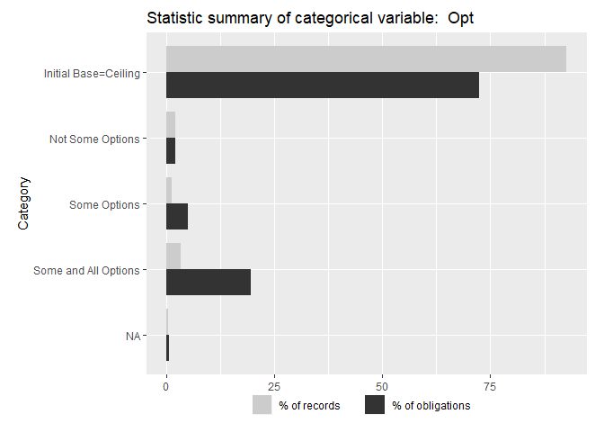

```r
grouped_barplot("Opt", def_serv)
```

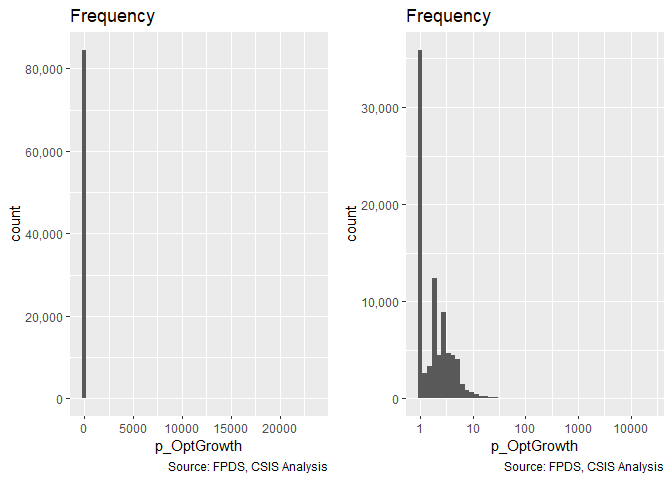

```r
freq_continuous_plot(def_serv %>%filter(AnyUnmodifiedUnexercisedOptions==1),"p_OptGrowth",bins=50, log=TRUE)
```

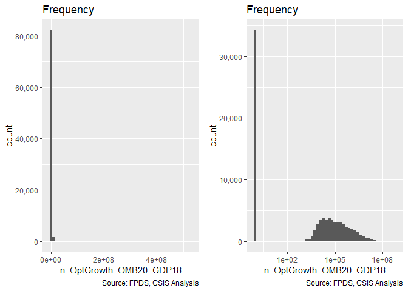

```r
freq_continuous_plot(def_serv %>%filter(AnyUnmodifiedUnexercisedOptions==1),"n_OptGrowth_OMB20_GDP18",bins=50, log=TRUE)
```

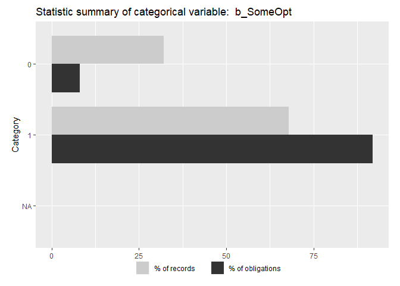

```r
grouped_barplot("b_SomeOpt", def_serv %>% dplyr::filter(AnyUnmodifiedUnexercisedOptions==1 ))
```

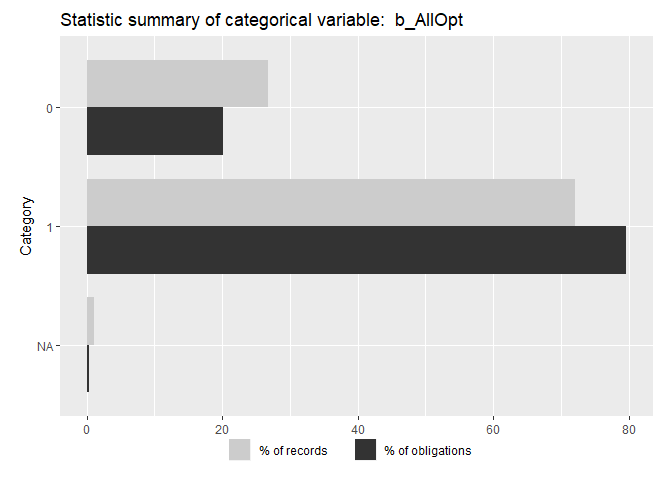

```r
grouped_barplot("b_AllOpt", def_serv %>% dplyr::filter(AnyUnmodifiedUnexercisedOptions==1 &
                                                              b_SomeOpt==1))
```

```r
statsummary_discrete("b_SomeOpt", def_serv %>% dplyr::filter(AnyUnmodifiedUnexercisedOptions==1 ))
```

```
##   b_SomeOpt % of records % of $s
## 1         0       32.05%   8.14%
## 2         1       67.89%  91.83%
## 3        NA        0.06%   0.03%
```

```r
statsummary_discrete("b_AllOpt", def_serv %>% dplyr::filter(AnyUnmodifiedUnexercisedOptions==1 &
                                                              b_SomeOpt==1))
```

```
##   b_AllOpt % of records % of $s
## 1        0       26.79%  20.17%
## 2        1       72.10%  79.54%
## 3       NA        1.11%   0.29%
```

### Ceiling Breaches

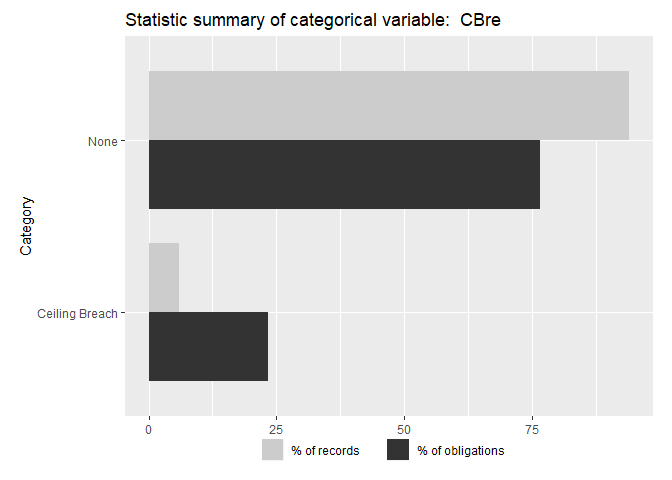

```r
grouped_barplot("CBre", def_serv)
```

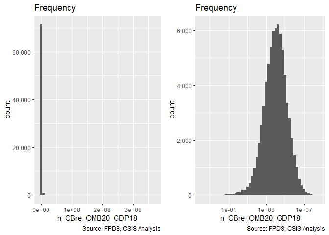

```r
freq_continuous_plot(def_serv %>%filter(b_CBre==1),"n_CBre_OMB20_GDP18",bins=50, log=TRUE)
```

```r
statsummary_discrete("CBre", def_serv)
```

```
##             CBre % of records % of $s
## 1           None       93.96%  76.60%
## 2 Ceiling Breach        6.04%  23.40%
```

```r
statsummary_continuous(c("n_CBre_OMB20_GDP18"), def_serv %>% dplyr::filter(b_CBre==1))
```

```
##        Variable_Name   Min             Max     Median Logarithmic Mean
## 1 n_CBre_OMB20_GDP18 0.000 367,080,377.479 10,583.141        9,750.761
##   1 unit below   1 unit above % of records NA
## 1      38.427  2,474,204.171            3.55%
##   % of Obligations to NA records
## 1                          5.34%
```

### Contract Terminations

Contract terminations and the number of change orders can be calculated for the entire sample. Contract termination is determined using the *Reason for Modification* field in FPDS. A contract is considered to be terminated if it has at least one modification with the following values:

- “Terminate for Default (complete or partial)”
- “Terminate for Convenience (complete or partial)”
- “Terminate for Cause”
- “Legal Contract Cancellation”

These four categories and the “Close Out” category are used to mark a contract as closed. Many contracts in FPDS and in the sample are never marked closed.

The original variables for b_Term is Term.

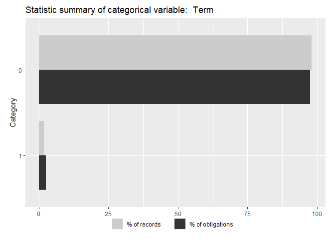

```r
grouped_barplot("Term", def_serv)
```

```r
statsummary_discrete(c("Term"), def_serv)
```

```
##   Term % of records % of $s
## 1    0       98.12%  97.54%
## 2    1        1.88%   2.46%
```

```r
#Overlaping ceiling breach and termination
nrow(def_serv %>% filter(b_Term==1 & b_CBre==1))
```

```
## [1] 1034
```

```r
sum((def_serv %>% filter(b_Term==1 & b_CBre==1))$Action_Obligation_OMB20_GDP18)
```

```
## [1] 4300188992
```

# Independent Variables

## Study Variables

### Service Complexity

The original variables for cln_US6sal is US6_avg_sal_lag1Const * cln_US6sal (“Detailed Industry Salary”) is a continuous variable that reports the Average U.S. wage in the contract’s detailed industry in the calendar year prior to contract start. Deflated to 2018 constant dollars based on the prior calendar year, logged, and rescaled. The variable is rescaled, by subtracting its mean (11) and dividing by its standard deviation doubled (0.799). Values of -1, -0.5, 0, 0.5, and 1 correspond to 26,033, 38,807, 57,851, 86,239, and 128,558 dollars respectively.

#### Detailed Industry Salary

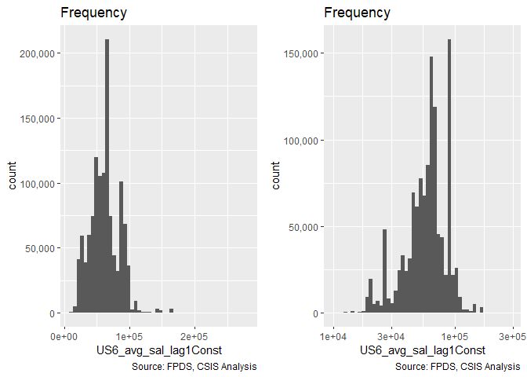

```r
freq_continuous_plot(def_serv,"US6_avg_sal_lag1Const",bins=50,
                     log=TRUE)
```

#### Service Code Invoice Rate

The original variables for cln_PSCrate is CFTE_Rate_1year

- cln_PSCrate (“Service Code Invoice Rate”) is a continuous variable that reports the average annual invoice rate for the contract’s product or service code in the fiscal year prior to contract start. In 2018 constant dollars based on the start fiscal year, logged and rescaled. The variable is rescaled, by subtracting its mean (12) and dividing by its standard deviation doubled (1). Values of -1, -0.5, 0, 0.5, and 1 correspond to 59,462, 98,226, 162,260, 268,037, and 442,771 dollars respectively.

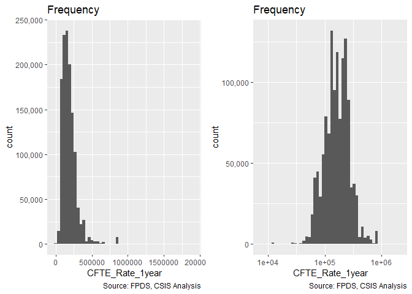

```r
freq_continuous_plot(def_serv,"CFTE_Rate_1year",bins=50,
                     log=TRUE)
```

```r
statsummary_continuous(c("US6_avg_sal_lag1Const","CFTE_Rate_1year"), def_serv)
```

```
##           Variable_Name       Min           Max      Median
## 1 US6_avg_sal_lag1Const 9,995.927   278,828.551  62,408.814
## 2       CFTE_Rate_1year 7,369.585 1,908,519.761 165,307.106
##   Logarithmic Mean 1 unit below 1 unit above % of records NA
## 1       57,850.656  26,032.696  128,557.502            2.95%
## 2      162,259.713  59,462.380  442,770.953            0.10%
##   % of Obligations to NA records
## 1                          1.10%
## 2                          0.04%
```

### Office Capacity

The variablecp_OffPerf7 is constructed by diving are the percentage form of office_PBSCobligated_1year / office_obligatedamount_1year

#### PBSC

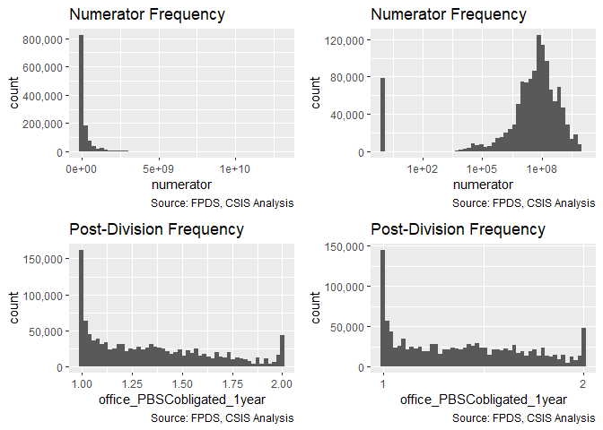

```r
freq_continuous_plot(def_serv,"office_PBSCobligated_1year",bins=50,
                     denominator="office_obligatedamount_1year",cap1=TRUE,log=TRUE,plus1=TRUE)
```

#### Office Experience withthe Product or Service Code

The original variables for cp_OffPerf7 is the percentage form of office_psc_obligatedamount_7year / office_obligatedamount_7year

- cp_OffPSC7 (“Office Service Code Experience”) is a continuous variable that reports the percentage of office 2018 constant obligations that went to contracts with the same product or service code as the product in question over the last 7 fiscal years, rescaled.

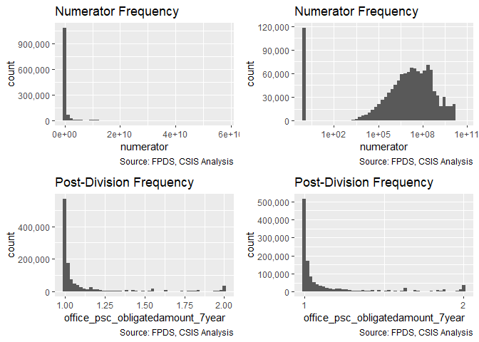

```r
#Absolute proporitonal psc spending
freq_continuous_plot(def_serv,"office_psc_obligatedamount_7year",bins=50,
                     denominator="office_obligatedamount_7year",cap1=TRUE,log=TRUE,plus1=TRUE)
```

```r
#See Number of Paired Years for the StatSummaryContinuous
```

### Office-Vendor Relationship

The original variables for cn_PairHist7 is office_entity_paircount_7year

- cn_PairHist7 (“Paired Years”) is a continuous variable that reports how many of the past 7 fiscal years involved obligations being made from the office to the vendor, recalled. The variable is rescaled, by subtracting its mean (3.51) and dividing by its standard deviation doubled(4.82). Values of -1, -0.5, 0, 0.5, and 1 correspond to -1.3, 1.1, 3.5, 5.9, and 8.3 number of years respectively.

#### Number of Paired Years

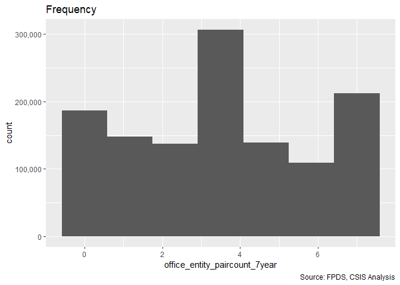

```r
freq_continuous_plot(def_serv,"office_entity_paircount_7year",bins=7)
```

```r
statsummary_continuous(c("pPBSC","pOffPSC","office_entity_paircount_7year"), def_serv,log=FALSE)
```

```
##                   Variable_Name   Min   Max Median Arithmatic Mean
## 1                         pPBSC 0.000 1.000  0.281           0.339
## 2                       pOffPSC 0.000 1.000  0.012           0.126
## 3 office_entity_paircount_7year 0.000 7.000  4.000           3.505
##   1 unit below 1 unit above % of records NA % of Obligations to NA records
## 1   -0.261  *        0.939           0.096%                         0.000%
## 2   -0.377  *        0.630           0.096%                         0.000%
## 3   -1.312  *     8.323  *           0.246%                         0.517%
```

#### Number of Prior Year Contract Action

The original variables for cln_PairCA is office_entity_numberofactions_1year

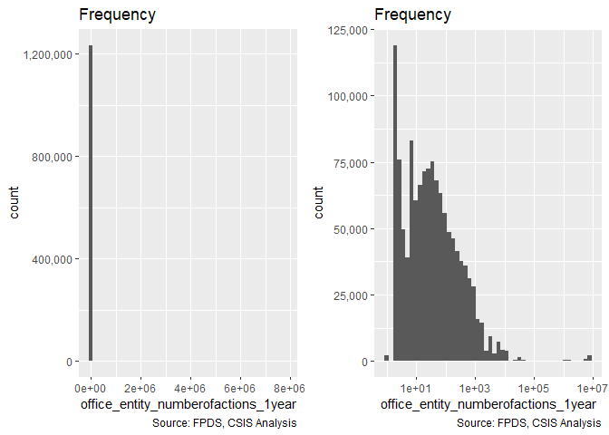

```r
freq_continuous_plot(def_serv,"office_entity_numberofactions_1year",bins=50, log=TRUE, plus1 = TRUE)
```

```r
statsummary_continuous(c("office_entity_numberofactions_1year"), def_serv, plus1=TRUE)
```

```
##                         Variable_Name   Min           Max Median
## 1 office_entity_numberofactions_1year 1.000 7,806,579.000 27.000
##   Logarithmic Mean 1 unit below 1 unit above % of records NA
## 1           34.012    0.491  *    2,355.033           0.246%
##   % of Obligations to NA records
## 1                         0.517%
```

## Contract-Level Controls

### Competition

Comp is derived from b_Comp to determine competition and UnmodifiedNumberOfOffersReceived to categorize competed contracts by offers

- Comp (Competition) is a categorical variable based on competition and the number of offers.
  - No Competition is its baseline value, for contracts that did not use competitive procedures.
  - 1Offr (1 Offer) for contracts that were competed but only recieved one offer.
  - 2-4Offr (2-4 Offers) for competed contracts receiving between 2 and 4 offers.
  - 5plusOffr (5+ Offers) 5+ Offers for competed contracts receiving 5 or more offers.

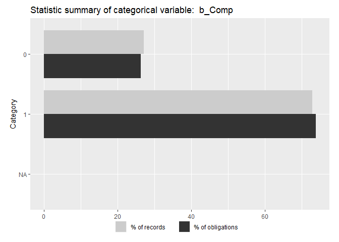

```r
grouped_barplot("b_Comp",def_serv)
```

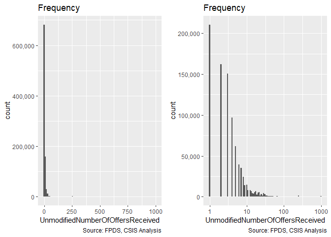

```r
freq_continuous_plot(def_serv %>% dplyr::filter(b_Comp==1), #Only Competed
                     "UnmodifiedNumberOfOffersReceived", bins=100,log=TRUE)
```

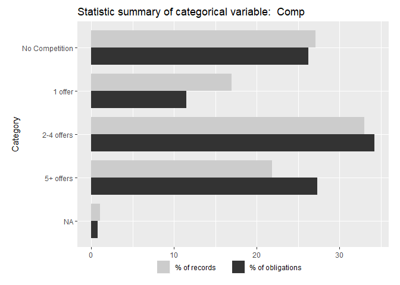

```r
grouped_barplot("Comp",def_serv)
```

```r
statsummary_discrete("Comp",def_serv)
```

```
##             Comp % of records % of $s
## 1 No Competition       27.14%  26.25%
## 2        1 offer       16.98%  11.48%
## 3     2-4 offers       33.00%  34.23%
## 4      5+ offers       21.83%  27.31%
## 5             NA        1.06%   0.73%
```

### Initial Contract Scope

#### Base

- cl_Ceil is the natural log of the initial contract cost ceiling, in then-year dollars. Data is missing for 0.00321 of records and 0.00548 of obligated dollars.

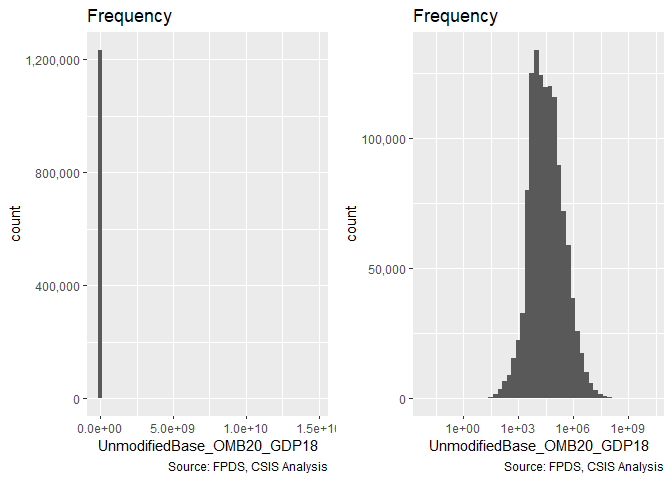

```r
#The original variables for cp_OffPerf7 is the ratio form of UnmodifiedBase_OMB20_GDP18

freq_continuous_plot(def_serv,"UnmodifiedBase_OMB20_GDP18",bins=50, log=TRUE)
```

#### Base:Ceiling Ratio

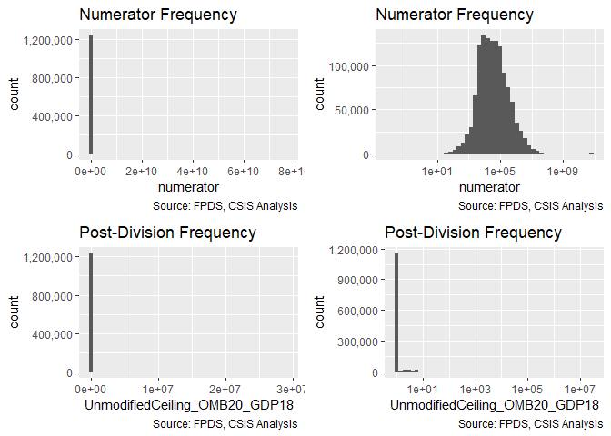

```r
#The original variables for cp_OffPerf7 is the ratio form of UnmodifiedCeiling_OMB20_GDP18 / UnmodifiedBase_OMB20_GDP18

freq_continuous_plot(def_serv,"UnmodifiedCeiling_OMB20_GDP18",bins=50,
                     denominator="UnmodifiedBase_OMB20_GDP18",log=TRUE)
```

#### Duration

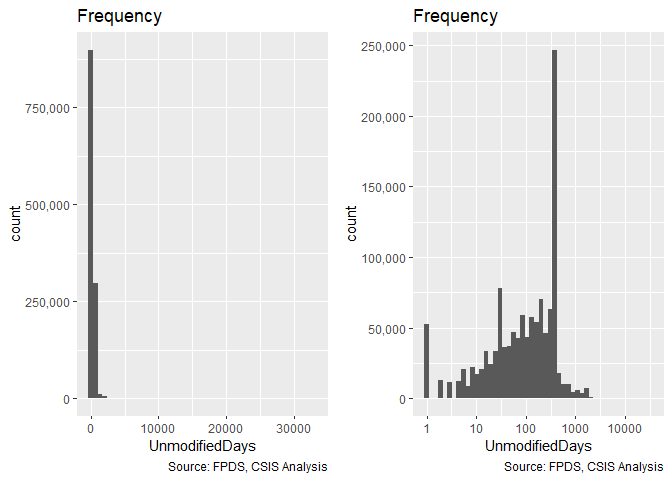

```r
#original variable for capped_cln_Days: UnmodifiedDays

freq_continuous_plot(def_serv,"UnmodifiedDays",bins=50, log=TRUE)
```

```r
statsummary_continuous(c("UnmodifiedBase_OMB20_GDP18","Base2Ceil","UnmodifiedDays"), def_serv)
```

```
##                Variable_Name   Min                Max     Median
## 1 UnmodifiedBase_OMB20_GDP18 0.009 14,756,841,090.022 30,043.570
## 2                  Base2Ceil 1.000     29,008,179.896      1.000
## 3             UnmodifiedDays 1.000         33,049.000    114.000
##   Logarithmic Mean 1 unit below   1 unit above % of records NA
## 1       34,224.128     469.889  2,492,697.987            0.52%
## 2            1.092    0.460  *          2.591            0.52%
## 3           78.537       2.809      2,195.777            2.31%
##   % of Obligations to NA records
## 1                          0.64%
## 2                          0.65%
## 3                          1.95%
```

### Contract Vehicle

- Comp (Competition) is a categorical variable based on whether there was a parent contract and if so of what type.
- It’s baseline value is for contracts that did not use competitive procedures. Other values are assigned based on the number of offers a competed contract received: 1 Offer, 2-4 Offers, 5+ Offers.
- Veh (Vehicle) is SIDV, MIDV, and FSS/GWAC, BPA/BOA are dummy variables based on the contract vehicle. They correspond to Single-Award IDVs, Multi-Award IDVs, and Other IDVs, respectively, having a value of 1 when the task order has that vehicle type, and having a 0 other. The remaining types, definitive contracts and purchase orders, are intentionally left out.

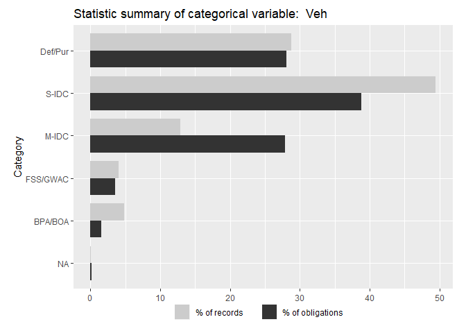

```r
grouped_barplot("Veh",def_serv)
```

```r
statsummary_discrete("Veh",def_serv)
```

```
##        Veh % of records % of $s
## 1  Def/Pur       28.76%  28.08%
## 2    S-IDC       49.40%  38.78%
## 3    M-IDC       12.91%  27.85%
## 4 FSS/GWAC        4.05%   3.54%
## 5  BPA/BOA        4.83%   1.58%
## 6       NA        0.05%   0.16%
```

### Pricing

Pricing is constructed using the two variables: PricingFee which tracks contract type and UCA, which tracks letter and undefinized contract actions.

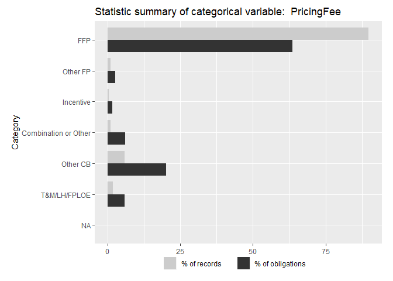

```r
grouped_barplot("PricingFee", def_serv)
```

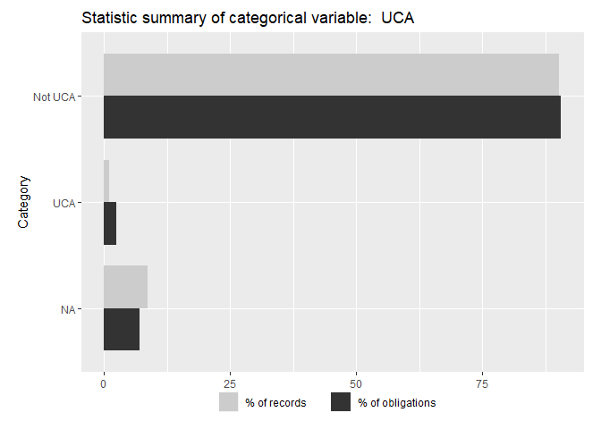

```r
grouped_barplot("UCA", def_serv)
```

```r
summary((def_serv %>% dplyr::filter(b_UCA==1))$PricingFee)
```

```
##                  FFP             Other FP            Incentive
##                10029                   49                   41
## Combination or Other             Other CB         T&M/LH/FPLOE
##                  196                 1864                  184
```

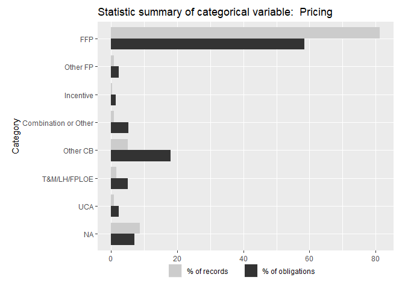

```r
grouped_barplot("Pricing", def_serv)
```

```r
statsummary_discrete("Pricing", def_serv)
```

```
##                Pricing % of records % of $s
## 1                  FFP       81.27%  58.50%
## 2             Other FP        0.89%   2.32%
## 3            Incentive        0.34%   1.42%
## 4 Combination or Other        0.91%   5.23%
## 5             Other CB        5.13%  17.98%
## 6         T&M/LH/FPLOE        1.71%   5.13%
## 7                  UCA        1.00%   2.37%
## 8                   NA        8.75%   7.04%
```

## Multilevel Controls

```r
nrow(def_serv)
```

```
## [1] 1241449
```

```r
length(unique(def_serv$NAICS3))
```

```
## [1] 108
```

```r
length(unique(def_serv$NAICS6))
```

```
## [1] 1059
```

```r
length(unique(paste(def_serv$NAICS6,def_serv$ServArea)))
```

```
## [1] 3825
```

```r
length(unique(def_serv$Agency))
```

```
## [1] 28
```

```r
length(unique(paste(def_serv$Agency,def_serv$Office)))
```

```
## [1] 1228
```

```r
length(unique(def_serv$Place))
```

```
## [1] 197
```

### Acquirer

#### Agency

- Agency is a factor reporting the top Contracting Agency of each contract. Data is missing for 0.000615 of records and -1.97e-08 of obligated dollars.

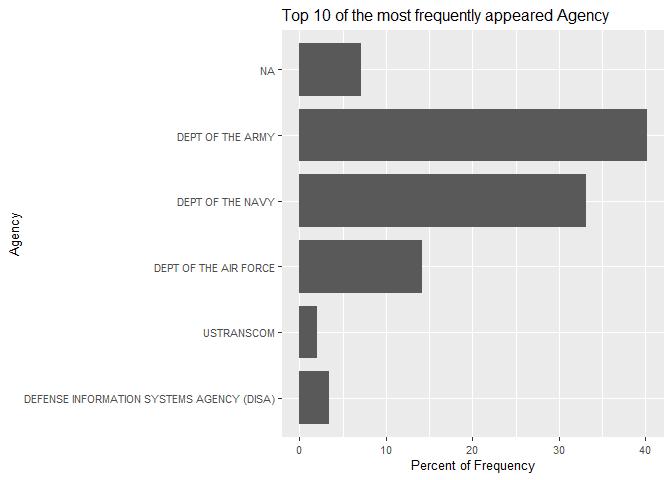

```r
#Percent grouped bar plot for variable Agency
#Generate new data frame containing frequency information
Agency_Freq <- as.data.frame(table(def_serv$Agency))
Agency_Freq$Percent_Freq <- round(Agency_Freq$Freq/sum(Agency_Freq$Freq),4)*100
colnames(Agency_Freq) <- c("Agency","Count_Freq","Percent_Freq")

Agency_Freq <- Agency_Freq[order(-Agency_Freq$Count_Freq),]
Agency_Freq <- Agency_Freq[1:10,]

#Add detail description to Agency code
Agency_Lookup <- read.csv("https://raw.githubusercontent.com/CSISdefense/Lookup-Tables/master/Agency_AgencyID.csv")
Agency_Lookup <- Agency_Lookup[,1:2]
colnames(Agency_Lookup) <- c("Agency","Agency_Description")

Agency_Freq <- left_join(Agency_Freq, Agency_Lookup, by = "Agency")
Agency_Freq$Agency <- factor(Agency_Freq$Agency, levels = rev(Agency_Freq$Agency))
Agency_Freq <- Agency_Freq[order(-Agency_Freq$Percent_Freq),]
Agency_Freq$Agency_Description <- factor(Agency_Freq$Agency_Description,
                                         levels=rev(Agency_Freq$Agency_Description))




#Add obligation percent information to data frame
Percent_Obli <- c()
for (i in Agency_Freq$Agency) {
  Percent_Obligation <- round(sum(def_serv$Action_Obligation_OMB20_GDP18[def_serv$Agency == i], na.rm = TRUE)/sum(def_serv$Action_Obligation_OMB20_GDP18, na.rm = TRUE),5)
  Percent_Obli <- c(Percent_Obli, Percent_Obligation)
}
Agency_Freq$Percent_Obli <- Percent_Obli*100

#Get top 5 Agencies that take largest percent obligation
Agency_Freq <- Agency_Freq[order(-Percent_Obli),]
Agency_Freq <- Agency_Freq[1:5,]
percent_freq_rest <- 100 - sum(Agency_Freq$Percent_Freq, na.rm = TRUE)
percent_obli_rest <- 100 - sum(Agency_Freq$Percent_Obli, na.rm = TRUE)

Agency_Freq[6,] <- c("All Other", "NA", percent_freq_rest, "All Other", percent_obli_rest)
Agency_Freq$Agency_Description <- factor(Agency_Freq$Agency_Description, levels = rev(Agency_Freq$Agency_Description))
Agency_Freq[,c(3,5)] <- lapply(Agency_Freq[,c(3,5)], function(x) as.numeric(x))
Agency_Freq <- melt(Agency_Freq, id = c("Agency","Count_Freq","Percent_Freq", "Agency_Description"))




#build the frequency bar plot
(
Frequency_Plot3 <- ggplot(data = Agency_Freq, aes(x=Agency_Description,        y=Percent_Freq)) +
                   geom_bar(stat = "identity", position = "dodge", width = 0.8) +
                   coord_flip() +
                   xlab("Agency") +
                   ylab("Percent of Frequency") +
                   theme_grey() +
                   scale_fill_grey() +
                   ggtitle("Top 10 of the most frequently appeared Agency") +
                   theme(text = element_text(size = 10))
)
```

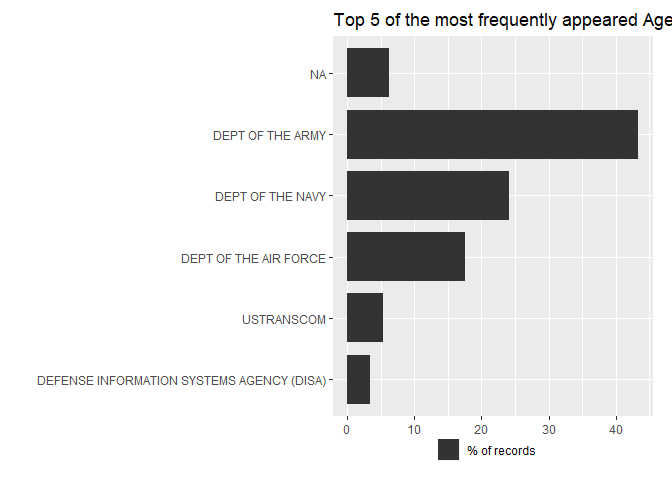

```r
#Build grouped bar plot
Agency_barplot <- ggplot(data = Agency_Freq,
                         aes(x = Agency_Description,
                             y=value,
                             fill=factor(variable))) +
                  geom_bar(stat = "identity",
                           position= "dodge",
                           width = 0.8) +
                  xlab("") +
                  ylab("") +
                  coord_flip() +
                  theme_grey() +
                  scale_fill_grey(labels = c("% of records", "% of obligation"),
                                  guide = guide_legend(reverse = TRUE)) +
                  theme(legend.title = element_blank(),
                        legend.position = "bottom",
                        legend.margin = margin(t=-0.8, r=0, b=0.5, l=0, unit = "cm"),
                        legend.text = element_text(margin = margin(r=0.5, unit = "cm")),
                        plot.margin = margin(t=0.3, r=0.5, b=0, l=0.5, unit = "cm")) +
                 ggtitle("Top 5 of the most frequently appeared Agency")
Agency_barplot
```

#### Office

- Office is a factor reporting the top Contracting office of each contract. Data is missing for 0.000957 of records and -1.83e-07 of obligated dollars.

```r
#grouped bar plot for variable Office
#Perpare data for plot
#get the detailed desceription for Office by AgencyID and OfficeID
# Office_Lookup <- read.delim("https://raw.githubusercontent.com/CSISdefense/Lookup-Tables/master/office/Office.ContractingOfficeCode.txt")
# def_dup <- def_serv

memory.limit(56000)
```

```
## [1] 56000
```

```r
Office_Freq <- def_serv %>% group_by(Office,ContractingOfficeName) %>% summarise(
  Count_Freq=length(CSIScontractID),
  Action_Obligation_OMB20_GDP18=sum(Action_Obligation_OMB20_GDP18)
)
```

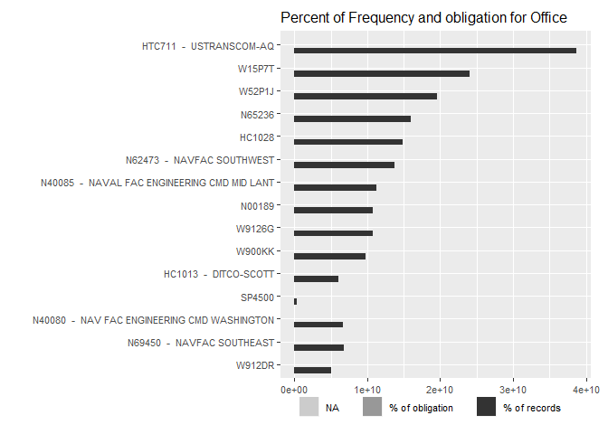

```r
  # Office_Freq <- Office_Freq[order(-Office_Freq$Freq),]
# Office_Freq_TOP20 <- Office_Freq[1:20,]   #Get top 20 NAICS6 has largest frequency count
Office_Freq$Percent_Freq <- round(Office_Freq$Count_Freq/
                                   sum(Office_Freq$Count_Freq),4)*100
Office_Freq$Percent_Obli <- round(Office_Freq$Action_Obligation_OMB20_GDP18/
                                         sum(Office_Freq$Action_Obligation_OMB20_GDP18),4)*100

colnames(Office_Freq)[colnames(Office_Freq)=="Office"] <- "OfficeID"
colnames(Office_Freq)[colnames(Office_Freq)=="ContractingOfficeName"] <- "OfficeName"

Office_Freq$Percent_Freq <- round(Office_Freq$Count_Freq/sum(Office_Freq$Count_Freq),4)*100
Office_Freq <- subset(Office_Freq, (Office_Freq$Count_Freq != 0)&(Office_Freq$Percent_Freq!=0))
Office_Freq[,1:2] <- lapply(Office_Freq[,1:2], function(x) as.character(x))

Office_Freq$Office_Full <- ifelse(is.na(Office_Freq$OfficeName), Office_Freq$OfficeID, Office_Freq$OfficeName)



Office_Freq_top10Freq <- Office_Freq[order(-Office_Freq$Percent_Freq),]
Office_Freq_top10Freq <- Office_Freq_top10Freq[1:10, ]  #including NULL category
Office_Freq_top10Obli <- Office_Freq[order(-Office_Freq$Percent_Obli),]
Office_Freq_top10Obli <- Office_Freq_top10Obli[1:10, ]  #including NULL category

Office_Freq_TOP <- rbind(Office_Freq_top10Obli, Office_Freq_top10Freq)
Office_Freq_TOP <- unique(Office_Freq_TOP)  #17 records in total

#Generate a new name column by Combining officeID and officeName
Office_Freq_TOP$Office_Full <- ifelse(Office_Freq_TOP$Office_Full == Office_Freq_TOP$OfficeID,
                                      Office_Freq_TOP$OfficeID,
                                      paste(Office_Freq_TOP$OfficeID,
                                            " - ",
                                            Office_Freq_TOP$OfficeName))

Office_Freq_TOP$Office_Full <- factor(Office_Freq_TOP$Office_Full,
                                      levels = rev(Office_Freq_TOP$Office_Full))
Office_Freq_TOP <- melt(Office_Freq_TOP,
                        id = c("OfficeID", "OfficeName", "Count_Freq", "Office_Full"))

(
Office_barplot <- ggplot(data = Office_Freq_TOP,
                         aes(x = Office_Full,
                             y = value,
                             fill = factor(variable))) +
                  geom_bar(stat = "identity",
                  position = "dodge",
                  width = 0.8) +
                  coord_flip() +
                  xlab("") +
                  ylab("") +
                  theme_grey() +
                  scale_fill_grey(labels = c("% of records", "% of obligation"),
                                  guide = guide_legend(reverse = TRUE)) +
                  ggtitle("Percent of Frequency and obligation for Office") +
                  theme(text = element_text(size = 10),
                        legend.title = element_blank(),
                        legend.position = "bottom",
                        legend.margin = margin(t=-0.8, r=0, b=0.5, l=0, unit = "cm"),
                        legend.text = element_text(margin = margin(r=0.5, unit = "cm")),
                        plot.margin = margin(t=0.3, r=0.5, b=0, l=0.5, unit = "cm"))
)
```

### Pair: Office and Vendor

#### pMarket

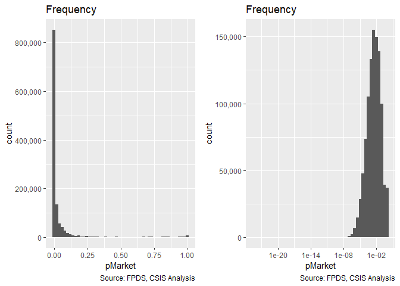

```r
freq_continuous_plot(def_serv,"pMarket",bins=50,log=TRUE)
```

```r
summary(def_serv$pMarket)
```

```
##    Min. 1st Qu.  Median    Mean 3rd Qu.    Max.    NA's
##  0.0000  0.0001  0.0019  0.0489  0.0192  1.0000    3052
```

### Economic Sector

#### NAICS 2

```r
# Add NAICS6 title
#def_serv$NAICS_Code<-create_naics2(def_serv$NAICS6)
def_serv$NAICS_Code<-def_serv$NAICS2


def_serv<-csis360::read_and_join_experiment(def_serv,
                            lookup_file = "Lookup_PrincipalNAICScode.csv",
                            path="https://raw.githubusercontent.com/CSISdefense/Lookup-Tables/master/",
                            dir="economic/",
                            by=c("NAICS_Code"="principalnaicscode"),
                            add_var="principalnaicscodeText"
)
```

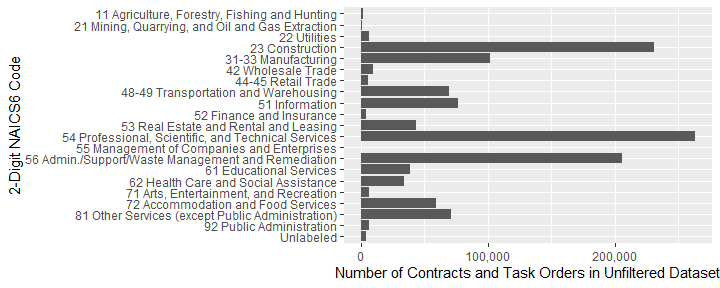

```r
def_serv$NAICS2_label<-paste(def_serv$NAICS_Code,
                             def_serv$principalnaicscodeText)

def_serv$NAICS2_label[
  def_serv$NAICS2_label==
    "56 Administrative and Support and Waste Management and Remediation Services"
  ]<-"56 Admin./Support/Waste Management and Remediation"
def_serv$NAICS2_label[def_serv$NAICS2_label==
                                    "NA NA"]<-"Unlabeled"

def_serv$NAICS2_label<-factor(def_serv$NAICS2_label)
order<-  rev(levels(def_serv$NAICS2_label))


NAICS2digit<-ggplot(def_serv,
       aes(x=NAICS2_label))+
  geom_bar()+coord_flip()+
  scale_y_continuous(label=scales::comma)+scale_x_discrete(limits=order)+
  labs(x="2-Digit NAICS6 Code",y="Number of Contracts and Task Orders in Unfiltered Dataset")

NAICS2digit
```

```r
ggsave(NAICS2digit,file="..\\Output\\NAICS2digitCount.png",width=10,height=6,dpi=600)
ggsave(NAICS2digit,file="..\\Output\\NAICS2digitCount.eps",width=10,height=6,dpi=600)
```

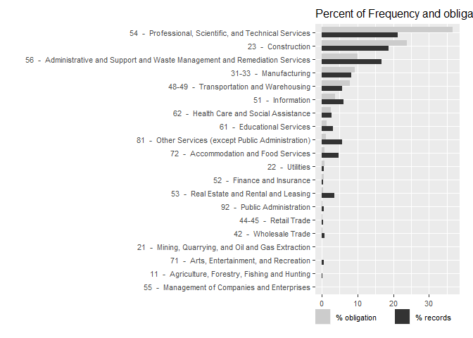

```r
#Prepare data for plot
NAICS2_Freq <- as.data.frame(table(def_serv$NAICS2))
NAICS2_Freq$Percent_Freq <- round(NAICS2_Freq$Freq/sum(NAICS2_Freq$Freq),4)*100
colnames(NAICS2_Freq) <- c("NAICS_Code", "Count_Freq", "Percent_Freq")




#Get detail description for NAICS2 code
NAICS2_Freq<-csis360::read_and_join_experiment(NAICS2_Freq,
                            lookup_file = "Lookup_PrincipalNAICScode.csv",
                            path="https://raw.githubusercontent.com/CSISdefense/Lookup-Tables/master/",
                            dir="economic/",
                            by=c("NAICS_Code"="principalnaicscode"),
                            add_var="principalnaicscodeText"
)
Percent_Obli <- c()
Total_Obli <- sum(def_serv$Action_Obligation_OMB20_GDP18, na.rm = TRUE)
for (i in NAICS2_Freq$NAICS_Code) {
  Percent_Obligation <- round(sum(def_serv$Action_Obligation_OMB20_GDP18[def_serv$NAICS2 == i], na.rm = TRUE)/Total_Obli,5)
  Percent_Obli <- c(Percent_Obli, Percent_Obligation)
}

NAICS2_Freq$Percent_Obli <- Percent_Obli * 100
NAICS2_Freq <- NAICS2_Freq[order(-NAICS2_Freq$Percent_Obli),]
NAICS2_Freq[,c(1,3)] <- lapply(NAICS2_Freq[,c(1,3)], function(x) as.character(x))
NAICS2_Freq$principalnaicscodeText <- paste(NAICS2_Freq$NAICS_Code, " - ", NAICS2_Freq$principalnaicscodeText)
NAICS2_Freq$principalnaicscodeText <- factor(NAICS2_Freq$principalnaicscodeText, levels = rev(NAICS2_Freq$principalnaicscodeText))
NAICS2_Freq <- melt(NAICS2_Freq, id = c("NAICS_Code", "Count_Freq","principalnaicscodeText"))
NAICS2_Freq$value <- as.numeric(NAICS2_Freq$value)

NAICS2_barplot <- ggplot(data = NAICS2_Freq,
                          aes(x = principalnaicscodeText,
                              y = value,
                              fill = factor(variable))) +
                   geom_bar(stat = "identity",
                            position = "dodge",
                            width = 0.8) +
                   coord_flip() +
                   xlab("") +
                   ylab("") +
                   theme_grey() +
                   scale_fill_grey(labels = c("% records", "% obligation"),
                                  guide = guide_legend(reverse = TRUE)) +
                   ggtitle("Percent of Frequency and obligation for NAICS2") +
                   theme(text = element_text(size = 10),
                         legend.title = element_blank(),
                         legend.position = "bottom",
                         legend.margin = margin(t=-0.8, r=0, b=0.5, l=0, unit = "cm"),
                         legend.text = element_text(margin = margin(r=0.5, unit = "cm")),
                         plot.margin = margin(t=0.3, r=0.5, b=0, l=0.5, unit = "cm"))
NAICS2_barplot
```

#### NAICS 3

```r
NAICS_summary<-def_serv %>% group_by(NAICS3,
                                     StartCY,
                                     def3_HHI_lag1,
                                     def3_obl_lag1,
                                     def3_ratio_lag1,
                                     US3_avg_sal_lag1) %>%
  dplyr::summarise(annual_action_obligation=sum(Action_Obligation_OMB20_GDP18),
                   annual_count=length(StartCY))

top_NAICS <- NAICS_summary %>% group_by(NAICS3) %>%
  dplyr::summarise(naics_action_obligation=sum(annual_action_obligation),
                   naics_count=sum(annual_count))
top_NAICS$naics_dollar_rank<-rank(-top_NAICS$naics_action_obligation)
top_NAICS$naics_count_rank<-rank(-top_NAICS$naics_count)


NAICS_summary<-left_join(NAICS_summary,top_NAICS, by="NAICS3")

colnames(NAICS_summary)[colnames(NAICS_summary)=="NAICS3"]<-"principalnaicscode"

NAICS_summary$principalnaicscode<-as.character(NAICS_summary$principalnaicscode)
NAICS_summary<-as.data.frame(NAICS_summary)
NAICS_summary<-read_and_join_experiment(NAICS_summary,
                                        lookup_file = "Lookup_PrincipalNAICScode.csv",
                                        path="https://raw.githubusercontent.com/CSISdefense/Lookup-Tables/master/",
                                        dir="economic/",
                                        by="principalnaicscode",
                                        skip_check_var=c("principalnaicscodeText",
                                                         "NAICS_shorthand",
                                                         "principalNAICS4DigitCode")
)
```

```r
# https://stackoverflow.com/questions/37174316/how-to-fit-long-text-into-ggplot2-facet-titles


centered_log_description(def_serv$def3_obl_lag1,"obligations")
```

```
## [1] "The variable is rescaled, by subtracting its mean (22.6) and dividing by its standard deviation doubled (4.12). Values of -1, -0.5, 0, 0.5, and 1 correspond to 1.1e+08, 8.5e+08, 6.7e+09, 5.3e+10, and 4.1e+11 obligations respectively."
```

```r
centered_log_description(def_serv$l_def6_obl_lag1,"obligations")
```

```
## [1] "The variable is rescaled, by subtracting its mean (3.02) and dividing by its standard deviation doubled (0.253). Values of -1, -0.5, 0, 0.5, and 1 correspond to 16, 18, 20, 23, and 26 obligations respectively."
```

```r
NA_stats(def_serv,"cl_def3_obl_lag1")
```

```
## [1] "Data is missing for 0.00644 of records and 0.00539 of obligated dollars."
```

```r
NA_stats(def_serv,"cln_Def6Obl")
```

```
## [1] "Data is missing for 0.0252 of records and 0.00884 of obligated dollars."
```

```r
centered_log_description(def_serv$def3_ratio_lag1,"obligations")
```

```
## [1] "The variable is rescaled, by subtracting its mean (-4.12) and dividing by its standard deviation doubled (3.06). Values of -1, -0.5, 0, 0.5, and 1 correspond to 0.00076, 0.0035, 0.016, 0.075, and 0.35 obligations respectively."
```

```r
centered_log_description(def_serv$def6_ratio_lag1,"obligations")
```

```
## [1] "The variable is rescaled, by subtracting its mean (-3.77) and dividing by its standard deviation doubled (4.56). Values of -1, -0.5, 0, 0.5, and 1 correspond to 0.00024, 0.0024, 0.023, 0.22, and 2.2 obligations respectively."
```

```r
NA_stats(def_serv,"clr_Def3toUS")
```

```
## [1] "Data is missing for 0.0117 of records and 0.00784 of obligated dollars."
```

```r
NA_stats(def_serv,"clr_Def6toUS")
```

```
## [1] "Data is missing for 0.0295 of records and 0.011 of obligated dollars."
```

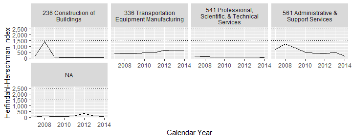

```r
# View(NAICS_summary)
NAICS_summary$NAICS_shorthand<-swr(NAICS_summary$NAICS_shorthand,nwrap = 25)
NAICS_summary$CY<-NAICS_summary$StartCY-1
NAICS3top<-ggplot(subset(NAICS_summary,naics_dollar_rank<=4 |
                          naics_count_rank<=4),
       aes(x=CY,y=def3_HHI_lag1))+#color=NAICS_Code
  geom_line()+
  scale_y_continuous(label=scales::comma)+
  # scale_x_continuous(breaks=c(2006,2009,2011,2014))+
  labs(x="Calendar Year",y="Herfindahl-Herschman Index")+
  geom_hline(yintercept=c(1500,2500),linetype="dotted")

NAICS3top_paper<-NAICS3top+ facet_wrap(~NAICS_shorthand,ncol=2)
ggsave(NAICS3top_paper,file="..\\Output\\NAICS3top.png",width=4,height=8,dpi=600)
ggsave(NAICS3top_paper,file="..\\Output\\NAICS3top.eps",width=4,height=8,dpi=600)

NAICS3top_pp<-NAICS3top+ facet_wrap(~NAICS_shorthand,ncol=4)
NAICS3top_pp
```

```r
ggsave(NAICS3top_pp,file="..\\Output\\NAICS3top_pp.png",width=10.5,height=5.5,dpi=600)
ggsave(NAICS3top_pp,file="..\\Output\\NAICS3top_pp.eps",width=10.5,height=5.5,dpi=600)

summary(NAICS_summary$naics_count_rank)
```

```
##    Min. 1st Qu.  Median    Mean 3rd Qu.    Max.
##    1.00   26.00   51.00   51.58   77.50  108.00
```

```r
NAICS_summary$NAICS_shorthand<-swr(NAICS_summary$NAICS_shorthand,nwrap = 16)
# NAICS_summary$CY<-factor(paste("'",substring(as.character(NAICS_summary$CY),3,4),sep=""))

NAICS3top8<-ggplot(subset(NAICS_summary,naics_dollar_rank<=8),
       aes(x=CY,y=def3_HHI_lag1))+#color=NAICS_Code
  geom_line()+
  scale_y_continuous(label=scales::comma)+
  scale_x_continuous(breaks=c(2007,2012))+
  labs(x="Calendar Year",y="Herfindahl-Herschman Index")+
  geom_hline(yintercept=c(1500,2500),linetype="dotted")

NAICS3top8_wide<-NAICS3top8+ facet_grid(.~NAICS_shorthand)
ggsave(NAICS3top8_wide,file="..\\Output\\NAICS3top8.png",width=9.5,height=4,dpi=600)
ggsave(NAICS3top8_wide,file="..\\Output\\NAICS3top8.eps",width=9.5,height=4,dpi=600)

colnames(NAICS_summary)
```

```
##  [1] "principalnaicscode"       "StartCY"
##  [3] "def3_HHI_lag1"            "def3_obl_lag1"
##  [5] "def3_ratio_lag1"          "US3_avg_sal_lag1"
##  [7] "annual_action_obligation" "annual_count"
##  [9] "naics_action_obligation"  "naics_count"
## [11] "naics_dollar_rank"        "naics_count_rank"
## [13] "principalnaicscodeText"   "principalNAICS2DigitCode"
## [15] "principalNAICS3DigitCode" "principalNAICS4DigitCode"
## [17] "NAICS_shorthand"          "CY"
```

```r
NAICS_long<-NAICS_summary[,colnames(NAICS_summary) %in% c( "principalnaicscode",
                                                    "def3_HHI_lag1",
                                                    "def3_obl_lag1",
                                                    "def3_ratio_lag1",
                                                    # "US3_avg_sal_lag1",
                                                    "naics_dollar_rank" ,
                                                    "naics_count_rank",
                                                    "principalnaicscodeText",
                                                     "NAICS_shorthand",
                                                    "CY")]
NAICS_long<-melt(NAICS_long, id=c("principalnaicscode","naics_dollar_rank","naics_count_rank","principalnaicscodeText","CY", "NAICS_shorthand"))



#Drop the ratios and average salaries w/ unique values
# NAICS_long<-NAICS_long[NAICS_long$variable %in% c(),]


levels(NAICS_long$variable)<- list("Herfindahl-\nHerschman Index"=c("def3_HHI_lag1"),
                                   "Defense Obligations"=c("def3_obl_lag1"),
                                   "Defense Obligations\nto U.S. Revenue Ratio"=c("def3_ratio_lag1"))

NAICS_long$high<-2500
NAICS_long$high[NAICS_long$variable!="Herfindahl-\nHerschman Index"]<-NA
NAICS_long$low<-1500
NAICS_long$low[NAICS_long$variable!="Herfindahl-\nHerschman Index"]<-NA


NAICS3long<-ggplot(subset(NAICS_long,naics_dollar_rank<=8),
       aes(x=CY,y=value))+#color=NAICS_Code
  geom_line()+
  scale_y_continuous(label=scales::comma)+
  scale_x_continuous(breaks=c(2007,2012))+
  labs(x="Calendar Year",y="Detailed Industry Metric")+
  geom_hline(aes(
           yintercept=high),linetype="dotted")+
  geom_hline(aes(
           yintercept=low),linetype="dotted")



NAICS3long_wide<-NAICS3long+ facet_grid(variable~NAICS_shorthand,scales="free_y")
ggsave(NAICS3long_wide,file="..\\Output\\NAICS3long.png",width=9.5,height=5.5,dpi=600)
ggsave(NAICS3long_wide,file="..\\Output\\NAICS3long.eps",width=9.5,height=5.5,dpi=600)
write.csv(NAICS_summary,file="..\\Output/NAICS3_summary.csv",row.names = FALSE)
```

```r
Frequency <- as.data.frame(table(def_serv$NAICS3))
Frequency[["Percent_Freq"]] <- round(Frequency[["Freq"]]/sum(Frequency[["Freq"]]),4)*100
colnames(Frequency) <- c("NAICS3", "Count_Freq", "Percent_Freq")
Percent_Obli <- c()
for (i in Frequency[["NAICS3"]]) {
  Percent_Obligation <- round(sum(def_serv[["Action_Obligation_OMB20_GDP18"]][def_serv$NAICS3 == i], na.rm = TRUE)/sum(def_serv[["Action_Obligation_OMB20_GDP18"]], na.rm = TRUE),5)
    Percent_Obli <- c(Percent_Obli, Percent_Obligation)
  }
Frequency[["Percent_Obli"]] <- Percent_Obli*100
NAICS3_Freq <- Frequency

#Add detail description to unique NAICS3 code
NAICS3_Freq<-read_and_join_experiment(NAICS3_Freq,
                                        lookup_file = "Lookup_PrincipalNAICScode.csv",
                                        path="https://raw.githubusercontent.com/CSISdefense/Lookup-Tables/master/",
                                        dir="economic/",
                                        by=c("NAICS3"="principalnaicscode"),
                                        skip_check_var=c("principalnaicscodeText",
                                                         "NAICS_shorthand",
                                                         "principalNAICS4DigitCode")
)
```

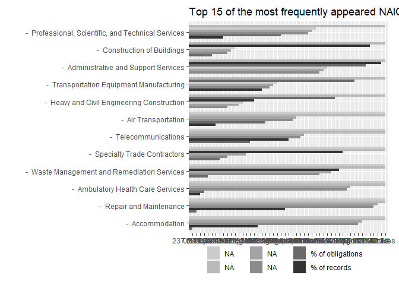

```r
colnames(NAICS3_Freq)[colnames(NAICS3_Freq)=="principalnaicscodeText"]<-"Description"
NAICS3_Freq$Description <- as.character(NAICS3_Freq$Description)
NAICS3_Freq$Description <- paste(NAICS3_Freq$NAICS6, " - ", NAICS3_Freq$Description)

#Get the top 15 most frequently appeared NAICS3
NAICS3_Freq_top10Freq <- NAICS3_Freq[order(-NAICS3_Freq$Percent_Freq),]
NAICS3_Freq_top10Freq <- NAICS3_Freq_top10Freq[1:10, ]
NAICS3_Freq_top10Obli <- NAICS3_Freq[order(-NAICS3_Freq$Percent_Obli),]
NAICS3_Freq_top10Obli <- NAICS3_Freq_top10Obli[1:10, ]
NAICS3_Freq_TOP <- rbind(NAICS3_Freq_top10Obli, NAICS3_Freq_top10Freq)
NAICS3_Freq_TOP <- unique(NAICS3_Freq_TOP)  #15 records in total
NAICS3_Freq_TOP <- NAICS3_Freq_TOP[order(-NAICS3_Freq_TOP$Percent_Obli),]
NAICS3_Freq_TOP$Description <- factor(NAICS3_Freq_TOP$Description, rev(NAICS3_Freq_TOP$Description))

#Reshape the dataframe to long format for plot
NAICS3_Freq_TOP <- melt(NAICS3_Freq_TOP, id = c("NAICS3", "Count_Freq", "Description"))

#Generate the plot and add title manually
part_grouped_barplot("NAICS3", NAICS3_Freq_TOP) + ggtitle("Top 15 of the most frequently appeared NAICS3")
```

#### NAICS 6

- NAICS6 is a factor reporting the top North American Industrial Classification Code of each contract. Data is missing for 0.00328 of records and 0.00301 of obligated dollars.

```r
NAICS_summary<-def_serv %>% group_by(NAICS6,StartCY,def6_HHI_lag1,def6_obl_lag1,def6_ratio_lag1,US6_avg_sal_lag1) %>%
  dplyr::summarise(annual_action_obligation=sum(Action_Obligation_OMB20_GDP18),
                   annual_count=length(StartCY))

top_NAICS <- NAICS_summary %>% group_by(NAICS6) %>%
  dplyr::summarise(naics_action_obligation=sum(annual_action_obligation),
                   naics_count=sum(annual_count))
top_NAICS$naics_dollar_rank<-rank(-top_NAICS$naics_action_obligation)
top_NAICS$naics_count_rank<-rank(-top_NAICS$naics_count)


NAICS_summary<-left_join(NAICS_summary,top_NAICS, by="NAICS6")

colnames(NAICS_summary)[colnames(NAICS_summary)=="NAICS6"]<-"principalnaicscode"

NAICS_summary$principalnaicscode<-as.character(NAICS_summary$principalnaicscode)
NAICS_summary<-as.data.frame(NAICS_summary)


NAICS_summary<-read_and_join_experiment(NAICS_summary,
                                                 lookup_file = "Lookup_PrincipalNAICScode.csv",
                                                 path="https://raw.githubusercontent.com/CSISdefense/Lookup-Tables/master/",
                                                 dir="economic/",
                                                 by="principalnaicscode",
                                                 skip_check_var=c("principalnaicscodeText",
                                                                  "NAICS_shorthand",
                                                                  "principalNAICS4DigitCode")

)
summary(NAICS_summary$NAICS_shorthand)
```

```
##    Length     Class      Mode
##      6347 character character
```

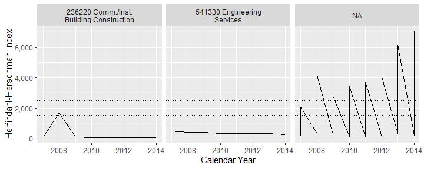

```r
# View(NAICS_summary)
NAICS_summary$NAICS_shorthand<-swr(NAICS_summary$NAICS_shorthand,nwrap = 25)
NAICS_summary$CY<-NAICS_summary$StartCY-1
NAICS6top<-ggplot(subset(NAICS_summary,naics_dollar_rank<=4 |
                          naics_count_rank<=4),
       aes(x=CY,y=def6_HHI_lag1))+#color=NAICS_Code
  geom_line()+
  scale_y_continuous(label=scales::comma)+
  # scale_x_continuous(breaks=c(2006,2009,2011,2014))+
  labs(x="Calendar Year",y="Herfindahl-Herschman Index")+
  geom_hline(yintercept=c(1500,2500),linetype="dotted")

NAICS6top_paper<-NAICS6top+ facet_wrap(~NAICS_shorthand,ncol=2)
ggsave(NAICS6top_paper,file="..\\Output\\NAICS6top.png",width=4,height=8,dpi=600)
ggsave(NAICS6top_paper,file="..\\Output\\NAICS6top.eps",width=4,height=8,dpi=600)

NAICS6top_pp<-NAICS6top+ facet_wrap(~NAICS_shorthand,ncol=4)
NAICS6top_pp
```

```r
ggsave(NAICS6top_pp,file="..\\Output\\NAICS6top_pp.png",width=10.5,height=5.5,dpi=600)
ggsave(NAICS6top_pp,file="..\\Output\\NAICS6top_pp.eps",width=10.5,height=5.5,dpi=600)

summary(NAICS_summary$naics_count_rank)
```

```
##    Min. 1st Qu.  Median    Mean 3rd Qu.    Max.
##     1.0   199.0   401.0   418.6   620.0  1018.5
```

```r
NAICS_summary$NAICS_shorthand<-swr(NAICS_summary$NAICS_shorthand,nwrap = 16)
# NAICS_summary$CY<-factor(paste("'",substring(as.character(NAICS_summary$CY),3,4),sep=""))

NAICS6top8<-ggplot(subset(NAICS_summary,naics_dollar_rank<=8),
       aes(x=CY,y=def6_HHI_lag1))+#color=NAICS_Code
  geom_line()+
  scale_y_continuous(label=scales::comma)+
  scale_x_continuous(breaks=c(2007,2012))+
  labs(x="Calendar Year",y="Herfindahl-Herschman Index")+
  geom_hline(yintercept=c(1500,2500),linetype="dotted")

NAICS6top8_wide<-NAICS6top8+ facet_grid(.~NAICS_shorthand)
ggsave(NAICS6top8_wide,file="..\\Output\\NAICS6top8.png",width=9.5,height=4,dpi=600)
ggsave(NAICS6top8_wide,file="..\\Output\\NAICS6top8.eps",width=9.5,height=4,dpi=600)


colnames(NAICS_summary)
```

```
##  [1] "principalnaicscode"       "StartCY"
##  [3] "def6_HHI_lag1"            "def6_obl_lag1"
##  [5] "def6_ratio_lag1"          "US6_avg_sal_lag1"
##  [7] "annual_action_obligation" "annual_count"
##  [9] "naics_action_obligation"  "naics_count"
## [11] "naics_dollar_rank"        "naics_count_rank"
## [13] "principalnaicscodeText"   "principalNAICS2DigitCode"
## [15] "principalNAICS3DigitCode" "principalNAICS4DigitCode"
## [17] "NAICS_shorthand"          "CY"
```

```r
NAICS_long<-NAICS_summary[,colnames(NAICS_summary) %in% c( "principalnaicscode",
                                                    "def6_HHI_lag1",
                                                    "def6_obl_lag1",
                                                    "def6_ratio_lag1",
                                                    # "US6_avg_sal_lag1",
                                                    "naics_dollar_rank" ,
                                                    "naics_count_rank",
                                                    "principalnaicscodeText",
                                                     "NAICS_shorthand",
                                                    "CY")]
NAICS_long<-melt(NAICS_long, id=c("principalnaicscode","naics_dollar_rank","naics_count_rank","principalnaicscodeText","CY", "NAICS_shorthand"))



#Drop the ratios and average salaries w/ unique values
# NAICS_long<-NAICS_long[NAICS_long$variable %in% c(),]


levels(NAICS_long$variable)<- list("Herfindahl-\nHerschman Index"=c("def6_HHI_lag1"),
                                   "Defense Obligations"=c("def6_obl_lag1"),
                                   "Defense Obligations\nto U.S. Revenue Ratio"=c("def6_ratio_lag1"))

NAICS_long$high<-2500
NAICS_long$high[NAICS_long$variable!="Herfindahl-\nHerschman Index"]<-NA
NAICS_long$low<-1500
NAICS_long$low[NAICS_long$variable!="Herfindahl-\nHerschman Index"]<-NA


NAICS6long<-ggplot(subset(NAICS_long,naics_dollar_rank<=8),
       aes(x=CY,y=value))+#color=NAICS_Code
  geom_line()+
  scale_y_continuous(label=scales::comma)+
  scale_x_continuous(breaks=c(2007,2012))+
  labs(x="Calendar Year",y="Detailed Industry Metric")+
  geom_hline(aes(
           yintercept=high),linetype="dotted")+
  geom_hline(aes(
           yintercept=low),linetype="dotted")



NAICS6long_wide<-NAICS6long+ facet_grid(variable~NAICS_shorthand,scales="free_y")
ggsave(NAICS6long_wide,file="..\\Output\\NAICS6long.png",width=9.5,height=5.5,dpi=600)
ggsave(NAICS6long_wide,file="..\\Output\\NAICS6long.eps",width=9.5,height=5.5,dpi=600)
write.csv(NAICS_summary,file="..\\Output/NAICS6_summary.csv",row.names = FALSE)
```

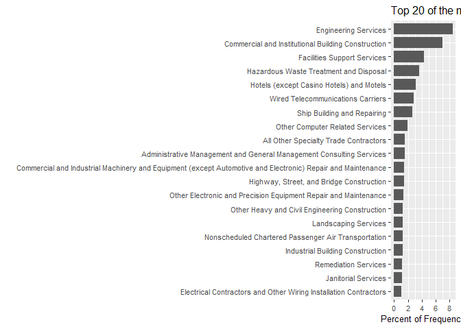

```r
#Prepare dateframe for plot
NAICS_Freq <- as.data.frame(table(def_serv$NAICS6))
NAICS_Freq <- NAICS_Freq[order(-NAICS_Freq$Freq),]
NAICS_Freq_TOP20 <- NAICS_Freq[1:20,]   #Get top 20 NAICS6 has largest frequency count
NAICS_Freq_TOP20$Percent_Freq <- round(NAICS_Freq_TOP20$Freq/sum(NAICS_Freq$Freq),4)*100
colnames(NAICS_Freq_TOP20) <- c("NAICS_Code", "Count_Freq", "Percent_Freq")

#Get detail description for each NAICS6 code
NAICS_Freq_TOP20<-read_and_join_experiment(NAICS_Freq_TOP20,
                                                 lookup_file = "Lookup_PrincipalNAICScode.csv",
                                                 path="https://raw.githubusercontent.com/CSISdefense/Lookup-Tables/master/",
                                                 dir="economic/",
                                                 by=c("NAICS_Code"="principalnaicscode"),
                                                 skip_check_var=c("principalnaicscodeText",
                                                                  "NAICS_shorthand",
                                                                  "principalNAICS4DigitCode")

)
NAICS_Freq_TOP20 <- NAICS_Freq_TOP20[order(-NAICS_Freq_TOP20$Percent_Freq),]
NAICS_Freq_TOP20$principalnaicscodeText <- factor(NAICS_Freq_TOP20$principalnaicscodeText, levels = rev(NAICS_Freq_TOP20$principalnaicscodeText))


Frequency_Plot <- ggplot(data = NAICS_Freq_TOP20,
                         aes(x = NAICS_Freq_TOP20$principalnaicscodeText,
                             y = NAICS_Freq_TOP20$Percent_Freq)) +
                  geom_bar(stat = "identity", position = "dodge", width = 0.8) +
                  coord_flip() +
                  xlab("") +
                  ylab("Percent of Frequency") +
                  theme_grey() +
                  scale_fill_grey() +
                  ggtitle("Top 20 of the most frequently appeared NAICS6") +
                  theme(text = element_text(size = 10))
Frequency_Plot
```

```r
#Percent frequency/obligation grouped bar plot for variable NAICS6
#Prepare dateframe for plot
NAICS_Freq <- def_serv %>% group_by(NAICS6) %>% summarise(
  Count_Freq=length(CSIScontractID),
  Action_Obligation_OMB20_GDP18=sum(Action_Obligation_OMB20_GDP18)
)

  # NAICS_Freq <- NAICS_Freq[order(-NAICS_Freq$Freq),]
# NAICS_Freq_TOP20 <- NAICS_Freq[1:20,]   #Get top 20 NAICS6 has largest frequency count
NAICS_Freq$Percent_Freq <- round(NAICS_Freq$Count_Freq/
                                   sum(NAICS_Freq$Count_Freq),4)*100
NAICS_Freq$Percent_Obli <- round(NAICS_Freq$Action_Obligation_OMB20_GDP18/
                                         sum(NAICS_Freq$Action_Obligation_OMB20_GDP18),4)*100

colnames(NAICS_Freq)[colnames(NAICS_Freq)=="NAICS6"] <- "NAICS_Code"
NAICS_Freq$NAICS_Code<-factor(NAICS_Freq$NAICS_Code)

#Get detail description for each NAICS6 code
NAICS_Freq<-read_and_join_experiment(NAICS_Freq,
                                                 lookup_file = "Lookup_PrincipalNAICScode.csv",
                                                 path="https://raw.githubusercontent.com/CSISdefense/Lookup-Tables/master/",
                                                 dir="economic/",
                                                 by=c("NAICS_Code"="principalnaicscode"),
                                                 skip_check_var=c("principalnaicscodeText",
                                                                  "NAICS_shorthand",
                                                                  "principalNAICS4DigitCode")

)
NAICS_Freq <- NAICS_Freq[order(-NAICS_Freq$Percent_Freq),]
NAICS_Freq$principalnaicscodeText <- factor(NAICS_Freq$principalnaicscodeText,
                                                   levels = rev(unique(NAICS_Freq$principalnaicscodeText)))




memory.limit(56000)
```

```
## [1] 56000
```

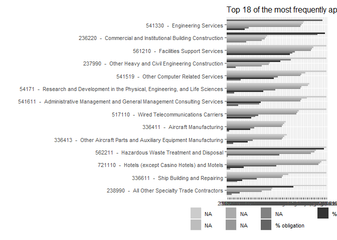

```r
NAICS_Freq_top10Freq <- NAICS_Freq[order(-NAICS_Freq$Percent_Freq),]
NAICS_Freq_top10Freq <- NAICS_Freq_top10Freq[1:10, ]
NAICS_Freq_top10Obli <- NAICS_Freq[order(-NAICS_Freq$Percent_Obli),]
NAICS_Freq_top10Obli <- NAICS_Freq_top10Obli[1:10, ]

NAICS_Freq_TOP <- rbind( NAICS_Freq_top10Obli, NAICS_Freq_top10Freq)
NAICS_Freq_TOP <- unique(NAICS_Freq_TOP)  #18 records in total
NAICS_Freq_TOP[,c(1,4)] <- lapply(NAICS_Freq_TOP[,c(1,4)], function(x) as.character(x))
NAICS_Freq_TOP$principalnaicscodeText <- paste(NAICS_Freq_TOP$NAICS_Code, " - ", NAICS_Freq_TOP$principalnaicscodeText)

NAICS_Freq_TOP$principalnaicscodeText <- factor(NAICS_Freq_TOP$principalnaicscodeText, levels = rev(NAICS_Freq_TOP$principalnaicscodeText))
NAICS_Freq_TOP <- melt(NAICS_Freq_TOP, id = c("NAICS_Code","Count_Freq","principalnaicscodeText"))
#NAICS_Freq_TOP <- merge(NAICS_Freq_top20Freq, NAICS_Freq_top20Obli, by= "NAICS_Code", all=TRUE)

(
NAICS_barPlot <- ggplot(data = NAICS_Freq_TOP,
                         aes(x = principalnaicscodeText,
                             y = value,
                             fill = factor(variable))) +
                  geom_bar(stat = "identity", position = "dodge", width = 0.8) +
                  coord_flip() +
                  xlab("") +
                  ylab("") +
                  theme_grey() +
                  scale_fill_grey(labels = c("% records", "% obligation"),
                                  guide = guide_legend(reverse = TRUE)) +
                  ggtitle("Top 18 of the most frequently appeared NAICS6") +
                  theme(text = element_text(size = 10),
                        legend.title = element_blank(),
                        legend.position = "bottom",
                        legend.margin = margin(t=-0.8, r=0, b=0.5, l=0, unit = "cm"),
                        legend.text = element_text(margin = margin(r=0.5, unit = "cm")),
                        plot.margin = margin(t=0.3, r=0.5, b=0, l=0.5, unit = "cm"))
)
```